# Bayesian Spatial Modeling of Malaria Prevalence in Mozambique using `inlabru`

Joaquín Martínez-Minaya

2024-12-16

# 1 Introduction

Bayesian spatial models are widely applied in health, ecology, and environmental sciences for analyzing spatially distributed data. Traditional approaches, such as Markov chain Monte Carlo (MCMC), are computationally expensive and often face convergence issues in large datasets.

The **Integrated Nested Laplace Approximation (INLA)** method offers an efficient alternative for Bayesian inference in latent Gaussian models. When combined with the **Stochastic Partial Differential Equation (SPDE)** approach, it enables the analysis of geostatistical data collected at specific locations, allowing for spatial prediction and the assessment of covariate effects.

This tutorial demonstrates the use of `inlabru` to model malaria prevalence in Mozambique. The provided data includes prevalence rates and covariates such as altitude, temperature, and proximity to water bodies. The goal is to fit a spatial Bayesian model to predict malaria risk and evaluate the effects of covariates using the **R-INLA** package.

For further reference, see the work of Moraga et al. (2021) on Bayesian spatial modeling in public health ([Moraga et al., 2021](https://www.sciencedirect.com/science/article/pii/S1877584521000393)).

# 2 Installing and Loading the Required Libraries

This section loads the necessary R packages, including **INLA**, **inlabru**, **sf**, and others, to perform spatial modeling.

```r
#install.packages("INLA", repos = "https://inla.r-inla-download.org/R/stable", dep = TRUE)
```

```r
# Loading necessary libraries
library(ggplot2)
library(dplyr)
library(INLA)
library(inlabru)
library(sf)
library(rnaturalearth)
library(patchwork)
library(leaflet)
```

# 3 Helper Functions

A utility function for scaling colors in plots is defined to assist in visualizing geospatial data. It is based on tutorials in the [inlabru website](https://inlabru-org.github.io/inlabru/).

```r
colsc <- function(...) {
  scale_color_gradientn(
    colors = rev(RColorBrewer::brewer.pal(11, "RdYlBu")),
    limits = range(..., na.rm = TRUE)
  )
}
```

# 4 Reading and Preparing the Data

This section prepares the data for fitting the Bayesian spatial model. It includes loading the geographic boundaries of Mozambique and loading the malaria prevalence data and covariates for predictions.

## 4.1 Boundaries of Mozambique

The boundaries of Mozambique are obtained using the `rnaturalearth` package. This provides geographic context for the analysis of malaria prevalence.

- **`ne_countries`** retrieves country-level geographic data. Mozambique is specified as the country of interest, and it is returned as an `sf` object for plotting and spatial analysis.

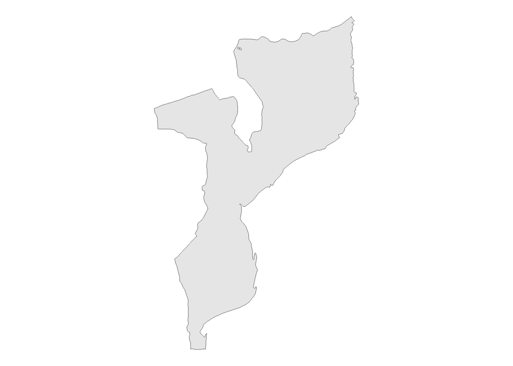

```r
# Loading the boundaries of Mozambique
mozambique_sf <- ne_countries(type = "countries", country = "Mozambique",
                              scale = "medium", returnclass = "sf")

# Plotting Mozambique's boundaries
ggplot(mozambique_sf) +
  geom_sf() +
  theme_void()
```

In the plot above, the boundaries of Mozambique are visualized using **ggplot2** and **geom_sf**, which are specifically designed for spatial data.

## 4.2 Data for Model Fitting

The dataset on malaria prevalence is loaded. It contains information such as the number of positive cases and the total number of examined individuals at specific locations. The ratio of positive cases to the total examined individuals represents the prevalence.

- **`sf::st_as_sf`** converts the data into an `sf` object, allowing the handling of spatial data with geographic coordinates (longitude and latitude).

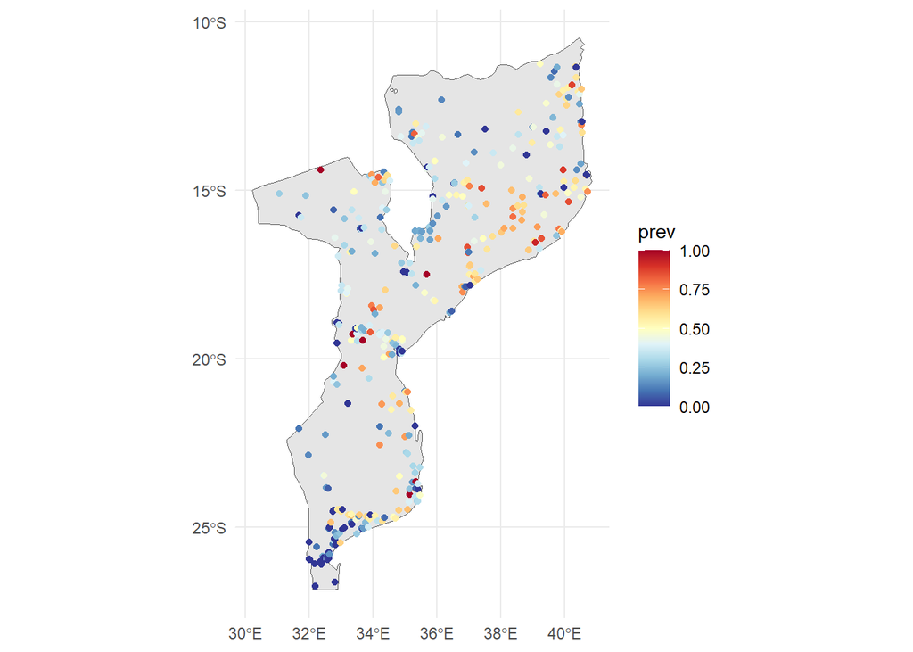

```r
# Loading the malaria prevalence data
d <- read.csv("https://raw.githubusercontent.com/Paula-Moraga/spatial-model-malaria/master/d.csv")

# Calculating prevalence as the ratio of positive cases to the total examined
d$prev <- d$positive/d$examined

# Converting the data to an sf object for spatial analysis
data <- sf::st_as_sf(
  d,
  coords = c("longitude", "latitude"),
  crs = 4326
)

# Plotting malaria prevalence across Mozambique
ggplot() +
    geom_sf(data = mozambique_sf, fill = "gray90") +
  geom_sf(data=data, aes(col = prev)) +
  colsc(data$prev) +
  theme_minimal()
```

In this step, the prevalence data is visualized using **ggplot2**. Each point on the map represents a location where data on malaria prevalence was collected. The color scale shows the variation in prevalence rates across different locations.

## 4.3 Data for Prediction

This dataset contains covariates such as altitude, temperature, and other environmental factors, which will be used to make predictions based on the fitted model.

- **`sf::st_as_sf`** is used again to convert the data into an `sf` object for spatial analysis.

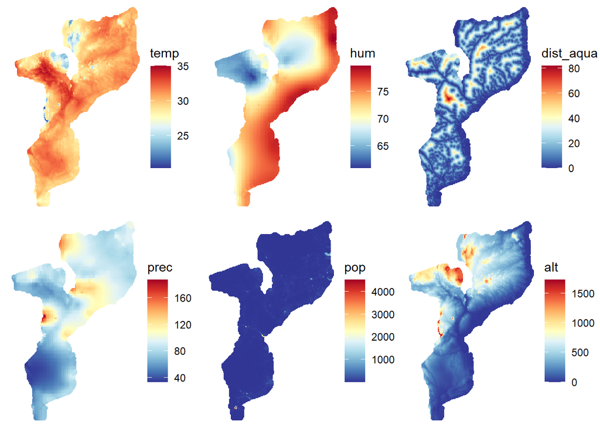

```r
# Loading the data for prediction, which contains covariates
dp <- read.csv("https://raw.githubusercontent.com/Paula-Moraga/spatial-model-malaria/master/dp.csv")
dp$alt <- dp$altitude

# Converting the covariate data to an sf object
dp_pred <- sf::st_as_sf(
  dp,
  coords = c("longitude", "latitude"),
  crs = 4326
)

# Visualizing one of the covariates (e.g., temperature)
plot_covs <- lapply(colnames(dp)[-c(1:4)], function(x){
  ggplot(dp_pred) +
  geom_sf(aes(col = !!sym(x))) +
  theme_void() +
  colsc(dp_pred[[x]])
})
multiplot(plotlist = plot_covs, cols = 3)
```

# 5 Fitting the Model

This section covers the process of creating the spatial mesh, defining priors, and fitting the Bayesian spatial model using **inlabru**.

## 5.1 Creating the Mesh

A mesh is created to discretize the spatial domain for the model. The mesh is essential in SPDE models as it defines the spatial structure, allowing the model to capture spatial dependence.

- **`fm_mesh_2d_inla`** creates a 2D mesh based on the boundary of Mozambique with specific settings for edge length and cutoff.
- The mesh is then plotted using **geom_fm** for visualization.

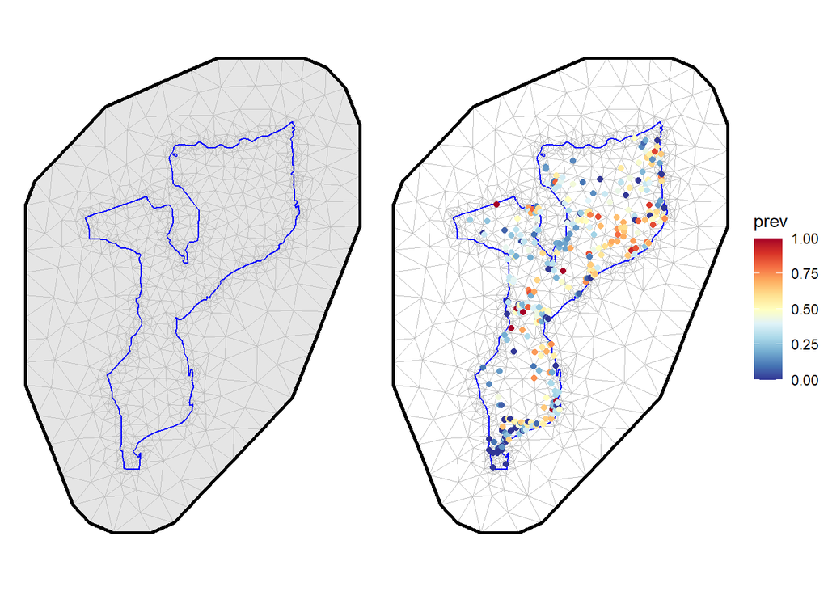

```r
mesh <- fm_mesh_2d_inla(boundary = mozambique_sf,
                        max.edge = c(1, 2),
                        cutoff = 0.05,
                        offset = c(1, 3),
                        crs    = 4326)

# Visualizing the mesh
mesh1 <- ggplot() +
  geom_fm(data = mesh) +
    theme_void()

# Combining the mesh with the malaria prevalence data
mesh2 <-ggplot() +
  geom_fm(data = mesh, fill = "white") +
  geom_sf(data = data, aes(col = prev)) +
  colsc(data$prev) +
  theme_void()

mesh1 | mesh2
```

The plots show how the mesh is constructed over the boundaries of Mozambique and how it relates to the malaria prevalence data.

## 5.2 Prior for the SPDE Model

Setting priors for the **SPDE** model is essential to encode prior beliefs about the model parameters. Here, we focus on setting priors for two parameters:

- **Range**: Describes how far the spatial effect extends before becoming negligible.
- **Sigma**: Represents the expected variability in the spatial field.

### 5.2.1 Prior for Sigma

The prior for **sigma** defines our belief about the variance of the spatial effect. Specifically, we set: - **sigma0** = 1 (threshold for the variance) - **p** = 0.01 (1% chance that the true variance exceeds sigma0)

This implies that:

$$P(\sigma > \sigma_0) = p$$

In the code, we define this prior as:

```r
prior.sigma = c(1, 0.01)
```

### 5.2.2 Prior for Range

For the **range**, which represents how far spatial effects are correlated, we set: - **r0**: Half the diameter of the spatial domain (calculated from the bounding box of the data). - **p** = 0.5 (50% chance that the range is shorter than this threshold).

This implies that:

$$P(r < r_0) = p$$

In the code, this prior is set as:

```r
prior.range = c(range0, 0.5)
```

```r
range0 <- st_bbox(data) %>%
  as.list(.) %>%
  as_tibble(.) %>%
  mutate(range0 = pmin(xmax-xmin, ymax-ymin)/2) %>%
  dplyr::select(range0) %>%
  dplyr::pull(.)

# Setting priors for SPDE model
matern <- inla.spde2.pcmatern(
  mesh = mesh,
  prior.range = c(range0, 0.5),
  prior.sigma = c(1, 0.01))
```

## 5.3 Fitting the Model with inlabru

Here, we define the components of the model and fit it using **inlabru**. The model includes fixed effects such as **altitude**, **temperature**, and other environmental covariates, as well as a spatial effect modeled using the SPDE.

- The model is fitted using **bru** with a **binomial** likelihood, and the number of trials (`Ntrials`) corresponds to the number of individuals examined for malaria at each location.

```r
# Defining model components
cmp <- positive ~ Intercept(1) + alt + temp + prec + hum + pop + dist_aqua +
  field(geometry, model = matern)

# Fitting the model
fit <- bru(cmp,
           data = data,
           family = "binomial",
           Ntrials = data$examined)
```

## 5.4 Posterior Distributions

After fitting the model, we analyze the posterior distributions of the fixed effects, hyperparameters, and spatial field.

### 5.4.1 Fixed Effects

The posterior distributions of the fixed effects, including the intercept and covariates, are plotted.

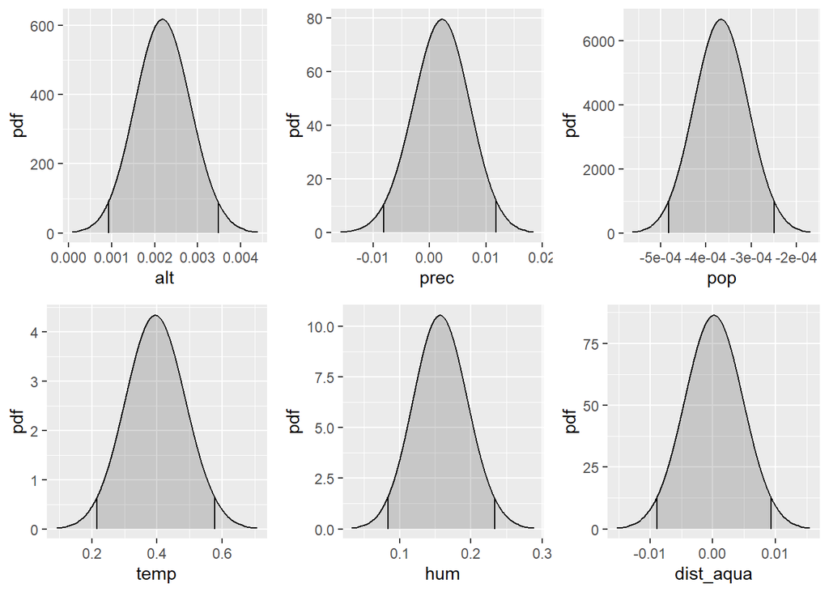

```r
# Plotting the posterior distribution of fixed effects
int.plot <- plot(fit, c("Intercept"))
fit$summary.fixed %>% rownames(.) %>%
  lapply(., function(x){plot(fit, x)}) -> plot_fixed

# Combining multiple plots
multiplot(plot_fixed[[2]], plot_fixed[[3]], plot_fixed[[4]],
          plot_fixed[[5]], plot_fixed[[6]], plot_fixed[[7]], cols = 3)
```

### 5.4.2 Hyperparameters

We also explore the posterior distributions of the hyperparameters, such as the spatial range and variance.

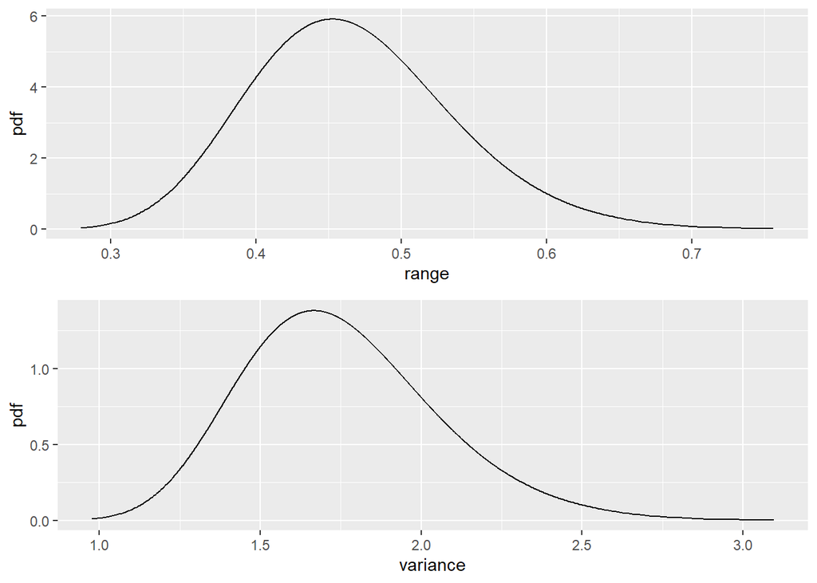

```r
# Plotting the posterior distribution of the spatial range and variance
spde.range <- spde.posterior(fit, "field", what = "range")
spde.var <- spde.posterior(fit, "field", what = "variance")

# Plotting range and variance
range.plot <- plot(spde.range)
var.plot <- plot(spde.var)

multiplot(range.plot, var.plot)
```

The plots above visualize the uncertainty in the spatial effect’s range and variance, providing insight into the model’s behavior.

## 5.5 Spatial Effect

Once the model is fitted, we predict the spatial effect and visualize both the **mean** and **standard deviation** (sd) of the spatial field. The spatial effect provides insight into how malaria risk varies across the geographic region.

- **`predict`** is used to make predictions based on the fitted model. The `field` component represents the spatial effect, and the family is set to **binomial** as we are modeling malaria prevalence.

The following code creates two plots: one for the mean of the spatial effect and one for the standard deviation. The two plots are combined into a single figure for better comparison.

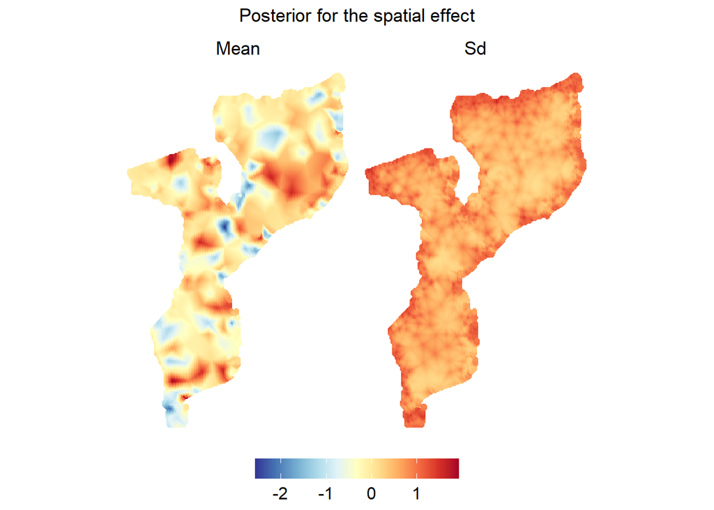

```r
# Predicting spatial effect
pred_sp <- predict(fit,
                   dp_pred,
                   ~ field,
                   family = "binomial")

# Plotting the mean of the spatial effect
mean_sp <- ggplot(pred_sp) +
  geom_sf(aes(col = mean)) +
  colsc(pred_sp$mean) +
  theme_void() +
  ggtitle("Mean") +
  theme(plot.title = element_text(hjust = 0.5),
        legend.title = element_blank())

# Plotting the standard deviation of the spatial effect
sd_sp <- ggplot(pred_sp) +
  geom_sf(aes(col = sd)) +
  colsc(pred_sp$mean) +
  theme_void() +
  ggtitle("Sd") +
  theme(plot.title = element_text(hjust = 0.5),
        legend.title = element_blank())

# Combining the plots for mean and sd
combined_plot_sp <- (mean_sp | sd_sp) +
  plot_layout(guides = "collect") +
  plot_annotation(title = "Posterior for the spatial effect",
                  theme = theme(plot.title = element_text(hjust = 0.5))) &
  theme(legend.position = "bottom",
        legend.text = element_text(size = 12)) &  # Increasing legend text size
  guides(color = guide_colorbar(barwidth = 10, barheight = 1))  # Adjusting color bar length

combined_plot_sp
```

The combined plot shows the predicted spatial field for malaria prevalence, with separate panels displaying the mean and standard deviation.

## 5.6 Correlation and Covariance Functions

The final step is to visualize the posterior correlation and covariance functions for the spatial field. These functions provide insight into how the spatial effect behaves over distance.

- **Correlation function**: Describes how the spatial effect at one location correlates with another as the distance between them increases.
- **Covariance function**: Measures the extent of variability in the spatial field over space.

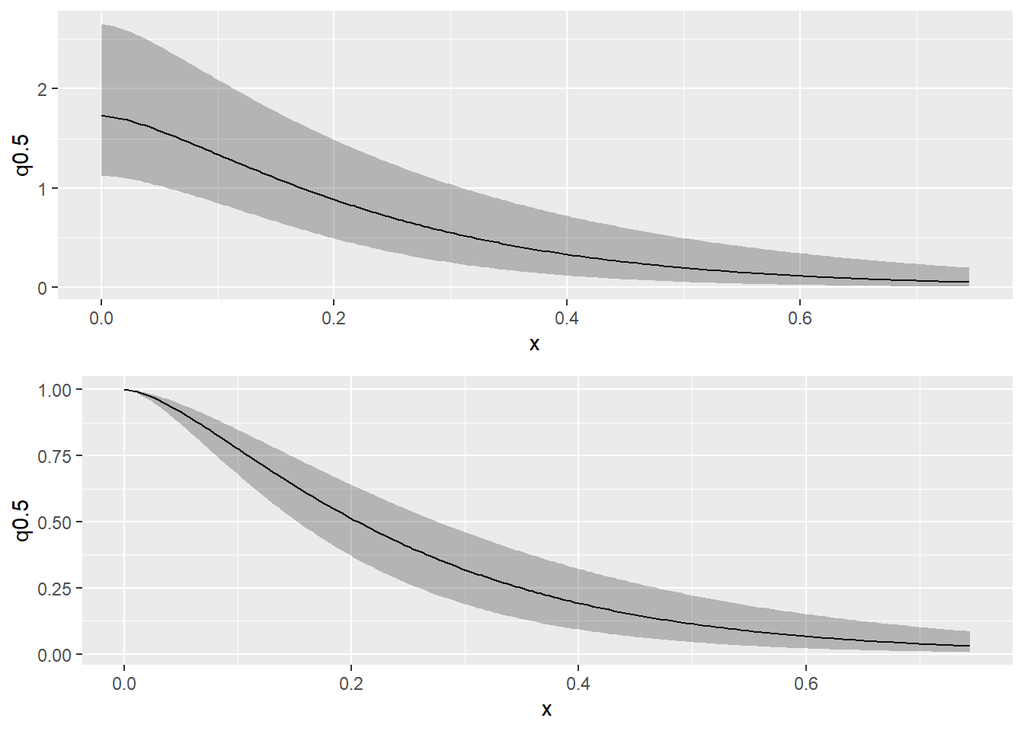

```r
# Plotting the posterior correlation and covariance functions
corplot <- plot(spde.posterior(fit, "field", what = "matern.correlation"))
covplot <- plot(spde.posterior(fit, "field", what = "matern.covariance"))

# Combining the plots for covariance and correlation
multiplot(covplot, corplot)
```

These plots help in understanding the structure of the spatial effect and how it varies across Mozambique.

# 6 Predictions

In this section, we make predictions using the fitted model and transform the predictions to probabilities using the inverse logit function. The **Invlogit** function converts the linear predictor from the model into probabilities for the binomial outcome (malaria prevalence).

```r
# Defining the inverse logit function
Invlogit <- function(x){
  res <- exp(x)/(1 + exp(x))
  res
}
```

We then use **predict** to generate predictions for the malaria prevalence based on the covariates from the prediction dataset (`dp_pred`). The predictions are transformed into probabilities using the inverse logit function.

```r
# Generating predictions for malaria prevalence
predictions <- predict(fit,
                       newdata = dp_pred,
                       ~data.frame(prob = Invlogit(field + Intercept + alt + temp + prec + hum + pop + dist_aqua)),
                       family = "binomial")
```

## 6.1 Visualizing Predictions

Two plots are created to visualize the **mean** and **standard deviation** (sd) of the predicted prevalence. These are combined into a single figure for comparison.

- **`mean_pred`**: Plot showing the mean predicted prevalence.
- **`sd_pred`**: Plot showing the standard deviation of the predicted prevalence.

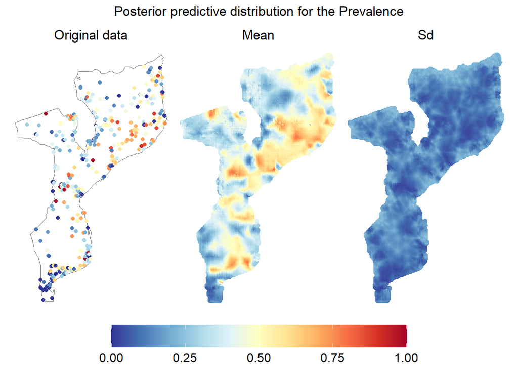

```r
# Creating a color scale for the plots
csc1 <- colsc(c(0, 1))

# Plotting the mean of the predicted prevalence
mean_pred <- ggplot(predictions) +
  geom_sf(aes(col = mean)) +
  csc1 +
  theme_void() +
  ggtitle("Mean") +
  theme(plot.title = element_text(hjust = 0.5),
        legend.title = element_blank())

# Plotting the standard deviation of the predicted prevalence
sd_pred <- ggplot(predictions) +
  geom_sf(aes(col = sd)) +
  csc1 +
  theme_void() +
  ggtitle("Sd") +
  theme(plot.title = element_text(hjust = 0.5),
        legend.title = element_blank())

# Original data
data_plot <- ggplot(mozambique_sf) +
  geom_sf(fill = "white") +
  geom_sf(data = data, aes(col = prev)) +
  colsc(data$prev) +
  theme_void() +
  ggtitle("Original data") +
    theme(plot.title = element_text(hjust = 0.5),
        legend.title = element_blank())

# Combining the plots for mean and sd
combined_plot <- (data_plot | mean_pred | sd_pred ) +
  plot_layout(guides = "collect") +
  plot_annotation(title = "Posterior predictive distribution for the Prevalence",
                  theme = theme(plot.title = element_text(hjust = 0.5))) &
  theme(legend.position = "bottom",
        legend.text = element_text(size = 12)) &  # Increase the legend text size
  guides(color = guide_colorbar(barwidth = 20, barheight = 1.5))  # Increase length of color bar

combined_plot
```

## 6.2 Adding Original Data Points

We can enhance the standard deviation plot by adding the original points for uncertainty. This plot highlights the areas where the standard deviation is higher, providing insight into where the model is less certain.

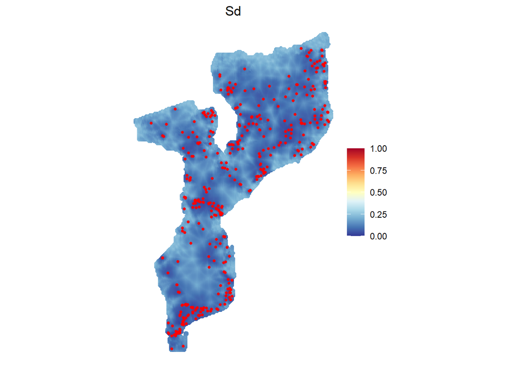

```r
# Adding original data points to the standard deviation plot
sd_pred_point <- sd_pred +
  geom_sf(data = data, aes(geometry = geometry), size = 1, color = "red")

sd_pred_point
```

## 6.3 Leaflet Map of Predicted Prevalence

Finally, we create an interactive leaflet map to visualize the predicted prevalence across Mozambique. Each circle on the map represents a location, with the color corresponding to the predicted prevalence.

- **Leaflet** is used to create an interactive map.
- **Color palette**: A viridis color palette is used to represent the predicted prevalence.

```r
# Creating a color palette for predicted prevalence
pal <- colorNumeric(palette = "viridis", domain = predictions$mean)

leaflet(predictions) %>%
  addProviderTiles("CartoDB.Positron") %>%
  setView(lng = 35.5, lat = -18.5, zoom = 5) %>%  # Ajusta la longitud, latitud y el nivel de zoom
  addCircleMarkers(
    fillColor = ~pal(mean),
    color = ~pal(mean),
    radius = 1.5,
    weight = 0.2,
    fillOpacity = 0.9,
    popup = ~paste("Prevalence:", mean)) %>%
  addLegend(
    pal = pal,
    values = predictions$mean,
    opacity = 0.9,
    title = "Prevalence",
    position = "bottomright"
  )
```

[interactive chart not shown]

This interactive map allows you to explore the predicted prevalence at different locations across Mozambique.